# Lecture 2 — Intermediate/Advanced BigQuery for GA4

GA4 BigQuery Analysis Report

Author

Bhamini Raghuram Pillai

Published

May 20, 2026

# 1 Introduction

This report demonstrates intermediate and advanced BigQuery concepts using the GA4 ecommerce sample dataset provided in Google BigQuery. The report includes SQL queries, explanations, and screenshots of outputs generated from BigQuery.

## 1.1 Query 1 — Total Users and New Users

### 1.1.1 Concept: CTEs (WITH)

This query uses a Common Table Expression (CTE) to identify total users and new users in the GA4 ecommerce dataset during November 2020. The query checks whether users triggered the `first_visit` or `first_open` event and classifies them as new users.

```sql
WITH UserInfo AS (

SELECT
  user_pseudo_id,

  MAX(
    IF(event_name IN ('first_visit', 'first_open'), 1, 0)
  ) AS is_new_user

FROM `bigquery-public-data.ga4_obfuscated_sample_ecommerce.events_*`

WHERE _TABLE_SUFFIX BETWEEN '20201101' AND '20201130'

GROUP BY user_pseudo_id

)

SELECT
  COUNT(*) AS total_users,
  SUM(is_new_user) AS new_users

FROM UserInfo;
```

[figure not shown]

## 1.2 Query 2 — Extract Page Location

### 1.2.1 Concept: Arrays + UNNEST

This query extracts the `page_location` parameter from the `event_params` array in the GA4 dataset. It demonstrates how to use `UNNEST` to retrieve nested values from arrays without expanding rows unnecessarily.

```sql
SELECT

TIMESTAMP_MICROS(event_timestamp) AS event_time,

(
SELECT value.string_value
FROM UNNEST(event_params)
WHERE key = 'page_location'
LIMIT 1
) AS page_location

FROM `bigquery-public-data.ga4_obfuscated_sample_ecommerce.events_*`

WHERE event_name = 'page_view'

AND _TABLE_SUFFIX BETWEEN '20201201' AND '20201202'

LIMIT 50;
```

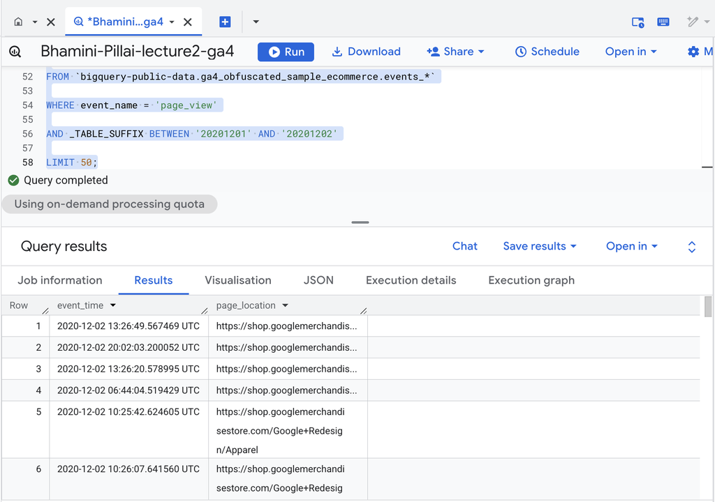

## 1.3 Query 3 — Item-Level Purchase Analysis

### 1.3.1 Concept: UNNEST + Item-Level Analysis

This query analyzes purchased products by flattening the `items` array using `UNNEST`. After unnesting, each row represents an individual item rather than a single event. The query counts how many times products appeared in purchase events during December 2020.

```sql
SELECT

event_date,

item.item_name,

COUNT(*) AS item_rows

FROM `bigquery-public-data.ga4_obfuscated_sample_ecommerce.events_*` e,

UNNEST(e.items) AS item

WHERE e.event_name = 'purchase'

AND _TABLE_SUFFIX BETWEEN '20201201' AND '20201231'

GROUP BY event_date, item.item_name

ORDER BY item_rows DESC

LIMIT 20;
```

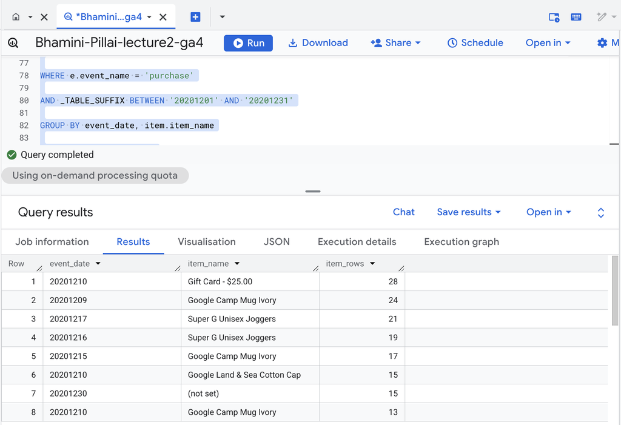

## 1.4 Query 4 — Events Seen Per Day

### 1.4.1 Concept: STRING_AGG

This query uses `STRING_AGG` to combine multiple event names into a single comma-separated list for each day. It helps summarize which user activities occurred during specific dates in the GA4 dataset.

```sql
SELECT

event_date,

STRING_AGG(
DISTINCT event_name,
', '
ORDER BY event_name
) AS events_seen

FROM `bigquery-public-data.ga4_obfuscated_sample_ecommerce.events_*`

WHERE _TABLE_SUFFIX BETWEEN '20201201' AND '20201203'

GROUP BY event_date

ORDER BY event_date;
```

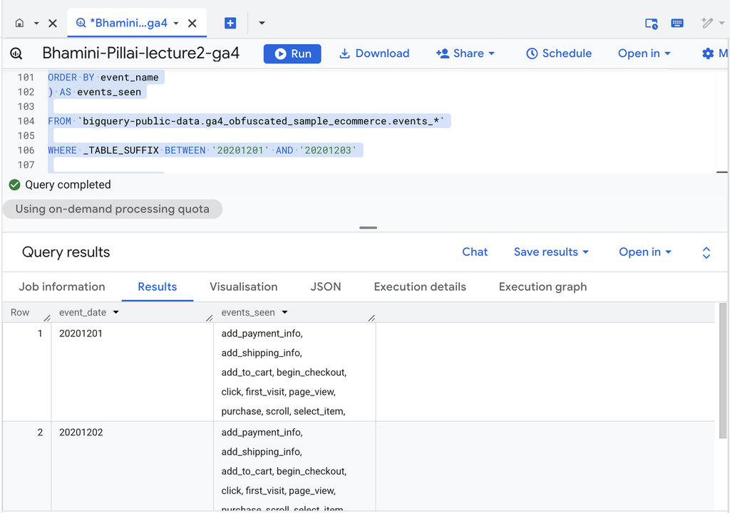

## 1.5 Query 5 — Items Added to Cart

### 1.5.1 Concept: ARRAY_AGG

This query uses `ARRAY_AGG` to create a list of items each user added to their cart. The query unnests the `items` array and groups products by user to summarize cart activity.

```sql
SELECT

user_pseudo_id,

ARRAY_AGG(item.item_name) AS items_added_to_cart

FROM `bigquery-public-data.ga4_obfuscated_sample_ecommerce.events_*`,

UNNEST(items) AS item

WHERE event_name = 'add_to_cart'

AND _TABLE_SUFFIX BETWEEN '20201201' AND '20201231'

GROUP BY user_pseudo_id

ORDER BY user_pseudo_id

LIMIT 10;
```

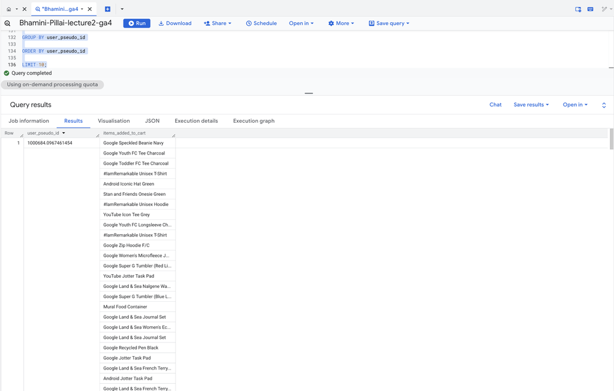

## 1.6 Query 6 — Session Cart Summary

### 1.6.1 Concept: ARRAY_AGG + STRUCT + Session Analysis

This query analyzes shopping cart activity at the session level. It extracts the GA session ID from nested event parameters and summarizes products added to cart during each session.

```sql
WITH add_to_cart AS (

SELECT

user_pseudo_id,

(
SELECT value.int_value
FROM UNNEST(event_params)
WHERE key = 'ga_session_id'
LIMIT 1
) AS session_id,

items

FROM `bigquery-public-data.ga4_obfuscated_sample_ecommerce.events_*`

WHERE event_name = 'add_to_cart'

AND _TABLE_SUFFIX BETWEEN '20210131' AND '20210131'

)

SELECT

user_pseudo_id,

session_id,

ARRAY_LENGTH(items) AS total_add_to_cart_items,

ARRAY_AGG(
STRUCT(
cart_items.item_id,
cart_items.item_name,
cart_items.quantity,
cart_items.price
)
) AS cart_items

FROM add_to_cart,

UNNEST(items) AS cart_items

GROUP BY user_pseudo_id, session_id

LIMIT 10;
```

[figure not shown]

# 2 Published Web Page

GitHub Pages Link: https://bhamini2606.github.io/lecture2-ga4/